# credit_python

```python
from urllib.request import urlretrieve
file_url = 'https://archive.ics.uci.edu/ml/machine-learning-databases/statlog/german/german.data'
urlretrieve(file_url, 'german.data')
```

```
('german.data', <http.client.HTTPMessage at 0x111844ef0>)
```

```python
import pandas as pd
columns = ['CheckingAccountStatus','Duration','CreditHistory','Purpose','Amount','SavingsAccountBonds', 'EmploymentDuration','InstallmentRatePercentage','Personal','OtherDebtorsGuarantors','ResidenceDuration','Property','Age','OtherInstallmentPlans','Housing','NumberExistingCredits','Job','NumberPeopleMaintenance','Telephone','ForeignWorker','Class']
full_data = pd.read_csv('german.data', sep=' ', header=None, names=columns)
```

```python
print(full_data.head())
print(full_data.info())
#data['CheckingAccountStatus'] = pd.Categorical(data['CheckingAccountStatus'].map({'A14':'none','A11':'lt.0','A12':'0.to.200','A13':'gt.200'}))
#print(data.info())
#print(data.head())
```

```
  CheckingAccountStatus  Duration CreditHistory Purpose  Amount  \
0                   A11         6           A34     A43    1169
1                   A12        48           A32     A43    5951
2                   A14        12           A34     A46    2096
3                   A11        42           A32     A42    7882
4                   A11        24           A33     A40    4870

  SavingsAccountBonds EmploymentDuration  InstallmentRatePercentage Personal  \
0                 A65                A75                          4      A93
1                 A61                A73                          2      A92
2                 A61                A74                          2      A93
3                 A61                A74                          2      A93
4                 A61                A73                          3      A93

  OtherDebtorsGuarantors  ...   Property Age  OtherInstallmentPlans Housing  \
0                   A101  ...       A121  67                   A143    A152
1                   A101  ...       A121  22                   A143    A152
2                   A101  ...       A121  49                   A143    A152
3                   A103  ...       A122  45                   A143    A153
4                   A101  ...       A124  53                   A143    A153

  NumberExistingCredits   Job NumberPeopleMaintenance  Telephone  \
0                     2  A173                       1       A192
1                     1  A173                       1       A191
2                     1  A172                       2       A191
3                     1  A173                       2       A191
4                     2  A173                       2       A191

  ForeignWorker Class
0          A201     1
1          A201     2
2          A201     1
3          A201     1
4          A201     2

[5 rows x 21 columns]
<class 'pandas.core.frame.DataFrame'>
RangeIndex: 1000 entries, 0 to 999
Data columns (total 21 columns):
CheckingAccountStatus        1000 non-null object
```

[output cut: 8 more lines]

```
OtherDebtorsGuarantors       1000 non-null object
ResidenceDuration            1000 non-null int64
Property                     1000 non-null object
Age                          1000 non-null int64
OtherInstallmentPlans        1000 non-null object
Housing                      1000 non-null object
NumberExistingCredits        1000 non-null int64
Job                          1000 non-null object
NumberPeopleMaintenance      1000 non-null int64
Telephone                    1000 non-null object
ForeignWorker                1000 non-null object
Class                        1000 non-null int64
dtypes: int64(8), object(13)
memory usage: 164.1+ KB
None
```

```python
Renamed_data = pd.DataFrame()
Renamed_data['CheckingAccountStatus'] = pd.Categorical(full_data['CheckingAccountStatus'].map({'A14':'none','A11':'lt.0','A12':'0.to.200','A13':'gt.200'}))

Renamed_data['CreditHistory'] = pd.Categorical(full_data['CreditHistory'].map({'A30':'NoCredit.AllPaid','A31':'ThisBank.AllPaid','A32':'PaidDuly','A33':'Delay','A34':'Critical'}))

Renamed_data['Purpose']= pd.Categorical(full_data['Purpose'].map({'A40':'NewCar','A41':'UsedCar','A42':'Furniture.Equipment','A43':'Radio.Television','A44':'DomesticAppliances','A45':'Repairs','A46':'Education','A47':'Vacation','A48':'Retiring','A49':'Business','A410':'Others'}))

Renamed_data['SavingsAccountBonds'] = pd.Categorical(full_data['SavingsAccountBonds'].map({'A61':'lt.100','A62':'100.to.500','A63':'500.to.1000','A64':'gt.1000','A65':'Unknown'}))

Renamed_data['EmploymentDuration'] = pd.Categorical(full_data['EmploymentDuration'].map({'A71':'Unemployed','A72':'0.to.1','A73':'1.to.4','A74':'4.to.7','A75':'gt.7'}))

full_data['Personal'] = full_data['Personal'].map({'A91':'MDivorced.Seperated','A92':'FNotSingle','A93':'MSingle','A94':'MMarried.Widowed','A95':'FSingle'})
Renamed_data['Sex'] = pd.Categorical(full_data.Personal.str[0])
Renamed_data['MaritalStatus'] = pd.Categorical(full_data.Personal.str[1:])
Renamed_data['OtherDebtorsGuarantors'] = pd.Categorical(full_data['OtherDebtorsGuarantors'].map({'A101':'None','A102':'CoApplicant','A103':'Guarantor'}))

Renamed_data['Property'] = pd.Categorical(full_data['Property'].map({'A121':'RealEstate','A122':'Insurance', 'A123':'CarsOthers','A124':'Unknown'}))

Renamed_data['OtherInstallmentPlans'] = pd.Categorical(full_data['OtherInstallmentPlans'].map({'A141':'Bank','A142':'Stores','A143':'None'}))

Renamed_data['Housing'] = pd.Categorical(full_data['Housing'].map({'A151':'Rent','A152':'Own','A153':'ForFree'}))

Renamed_data['Job'] = pd.Categorical(full_data['Job'].map({'A171':'UnemployedUnskilled','A172':'UnskilledResident','A173':'SkilledEmployee','A174':'Management.SelfEmp.HighlyQualified'}))

Renamed_data['Telephone'] = pd.Categorical(full_data['Telephone'].map({'A191':0,'A192':1}))

Renamed_data['ForeignWorker'] = pd.Categorical(full_data['ForeignWorker'].map({'A201':1,'A202':0}))

Age_interval = (0,25,40,60,65,100)
categ = ['Student','Young','Adult','MidSenior','Senior']
Renamed_data['Age'] = full_data['Age']
Renamed_data['AgeBin'] = pd.cut(full_data.Age,Age_interval,labels=categ)
#data[['sex']] = data[['Personal']].apply(lambda x:x.split('_')[0])
month_interval = (0,12,24,36,48,60,72,84)
length = ['lt.1','1.to.2','2.to.3','3.to.4','4.to.5','5.to.6','6.to.7']
Renamed_data['Duration'] = full_data['Duration']
Renamed_data['DurationBin'] = pd.cut(full_data.Duration,month_interval,labels=length)
Renamed_data['InstallmentRatePercentage'] = pd.Categorical(full_data['InstallmentRatePercentage'].map({1:'1',2:'2',3:'3',4:'4'}))
Renamed_data['ResidenceDuration'] = pd.Categorical(full_data['ResidenceDuration'].map({1:'1',2:'2',3:'3',4:'4'}))
Renamed_data['NumberExistingCredits'] = pd.Categorical(full_data['NumberExistingCredits'].map({1:'1',2:'2',3:'3',4:'4'}))
Renamed_data['NumberPeopleMaintenance'] = pd.Categorical(full_data['NumberPeopleMaintenance'].map({1:'1',2:'2'}))

credit_interval = (0,500,1000,1500,2500,5000,7500,10000,15000,20000,30000)
credit = ['0.to.500','500.to.1000','1000.to.1500','1500.to.2500','2500.to.5000','5000.to.7500','7500.to.10000','10000.to.15000','15000.to.20000','20000.to.30000']
Renamed_data['AmountBin']=pd.cut(full_data.Amount,credit_interval,labels=credit)
Renamed_data['Amount'] = full_data['Amount']
Renamed_data['Class'] = pd.Categorical(full_data['Class'].map({1:'Good',2:'Bad'}))
```

```python
print(Renamed_data.head(5))
print(Renamed_data.info())
#print(data.describe())
```

```
  CheckingAccountStatus CreditHistory              Purpose  \
0                  lt.0      Critical     Radio.Television
1              0.to.200      PaidDuly     Radio.Television
2                  none      Critical            Education
3                  lt.0      PaidDuly  Furniture.Equipment
4                  lt.0         Delay               NewCar

  SavingsAccountBonds EmploymentDuration Sex MaritalStatus  \
0             Unknown               gt.7   M        Single
1              lt.100             1.to.4   F     NotSingle
2              lt.100             4.to.7   M        Single
3              lt.100             4.to.7   M        Single
4              lt.100             1.to.4   M        Single

  OtherDebtorsGuarantors    Property OtherInstallmentPlans  ...    AgeBin  \
0                   None  RealEstate                  None  ...    Senior
1                   None  RealEstate                  None  ...   Student
2                   None  RealEstate                  None  ...     Adult
3              Guarantor   Insurance                  None  ...     Adult
4                   None     Unknown                  None  ...     Adult

  Duration DurationBin InstallmentRatePercentage  ResidenceDuration  \
0        6        lt.1                         4                  4
1       48      3.to.4                         2                  2
2       12        lt.1                         2                  3
3       42      3.to.4                         2                  4
4       24      1.to.2                         3                  4

  NumberExistingCredits  NumberPeopleMaintenance      AmountBin Amount Class
0                     2                        1   1000.to.1500   1169  Good
1                     1                        1   5000.to.7500   5951   Bad
2                     1                        2   1500.to.2500   2096  Good
3                     1                        2  7500.to.10000   7882  Good
4                     2                        2   2500.to.5000   4870   Bad

[5 rows x 25 columns]
<class 'pandas.core.frame.DataFrame'>
RangeIndex: 1000 entries, 0 to 999
Data columns (total 25 columns):
CheckingAccountStatus        1000 non-null category
```

[output cut: 12 more lines]

```
ForeignWorker                1000 non-null category
Age                          1000 non-null int64
AgeBin                       1000 non-null category
Duration                     1000 non-null int64
DurationBin                  1000 non-null category
InstallmentRatePercentage    1000 non-null category
ResidenceDuration            1000 non-null category
NumberExistingCredits        1000 non-null category
NumberPeopleMaintenance      1000 non-null category
AmountBin                    1000 non-null category
Amount                       1000 non-null int64
Class                        1000 non-null category
dtypes: category(22), int64(3)
memory usage: 49.0 KB
None
```

```python
import matplotlib.pyplot as plt
import seaborn as sns
```

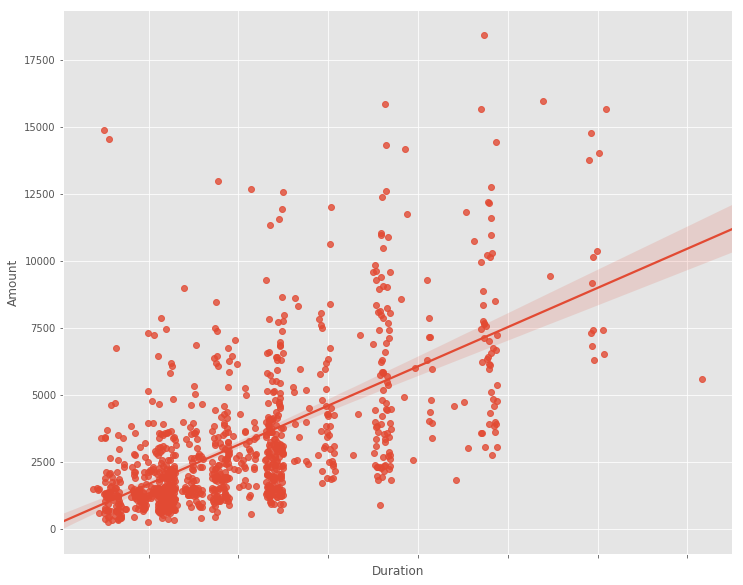

```python
plt.style.use('ggplot')
plt.figure(figsize=(12,10))
g = sns.regplot(x='Duration',y='Amount',data=Renamed_data,x_jitter=1)
g.set_xticklabels(g.get_xticklabels(),rotation=90)
plt.show()
```

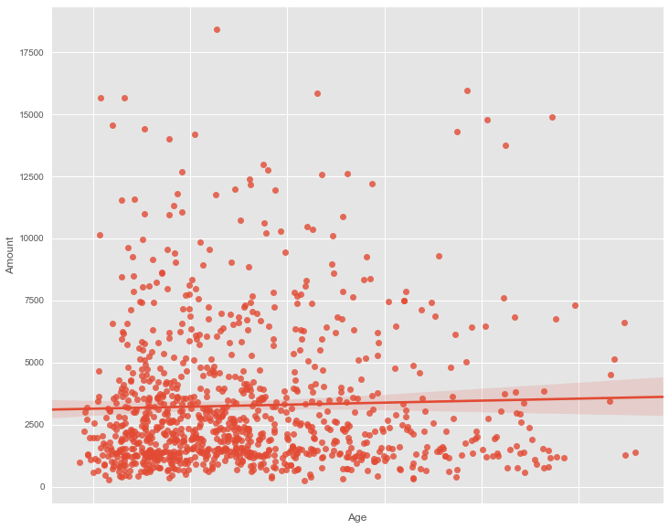

```python
plt.style.use('ggplot')
plt.figure(figsize=(12,10))
g = sns.regplot(x='Age',y='Amount',data=data,x_jitter=1)
g.set_xticklabels(g.get_xticklabels(),rotation=90)
plt.show()
```

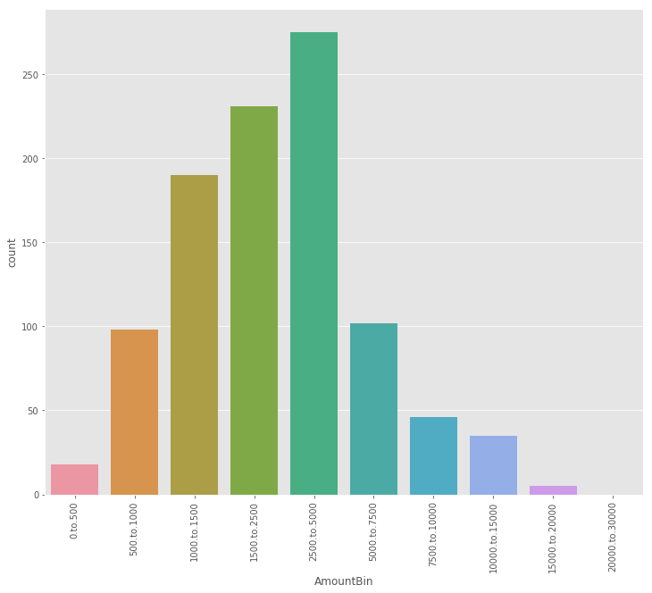

```python
plt.style.use('ggplot')
plt.figure(figsize=(12,10))
p = sns.countplot(x='AmountBin',data=Renamed_data)
p.set_xticklabels(p.get_xticklabels(),rotation=90)
plt.show()
```

```
Values describe:
Class                  Bad  Good
CheckingAccountStatus
0.to.200               105   164
gt.200                  14    49
lt.0                   135   139
none                    46   348
```

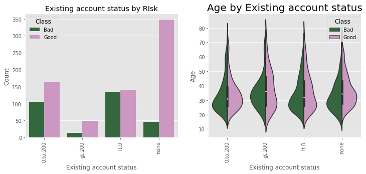

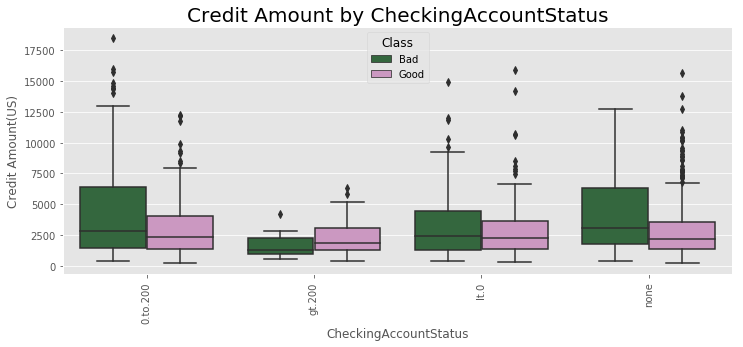

```python
print("Values describe: ")
print(pd.crosstab(Renamed_data.CheckingAccountStatus, Renamed_data.Class))
plt.style.use('ggplot')
plt.figure(figsize=(12,10))
g=plt.subplot(221)
g = sns.countplot(x='CheckingAccountStatus',data=Renamed_data,hue='Class',palette='cubehelix')
g.set_xlabel('Existing account status',fontsize=12)
g.set_ylabel('Count',fontsize=12)
g.set_title('Existing account status by RIsk')
g.set_xticklabels(g.get_xticklabels(),rotation=90)

g1 = plt.subplot(222)
g1 = sns.violinplot(x='CheckingAccountStatus',y='Age',data=Renamed_data,palette='cubehelix',hue='Class',split=True)
g1.set_xlabel("Existing account status", fontsize=12)
g1.set_ylabel("Age", fontsize=12)
g1.set_title("Age by Existing account status", fontsize=20)
g1.set_xticklabels(g.get_xticklabels(),rotation=90)

plt.show()
plt.figure(figsize=(12,10))
g2 = plt.subplot(212)
g2 = sns.boxplot(x="CheckingAccountStatus",y="Amount", data=Renamed_data,hue='Class',palette="cubehelix")
g2.set_xlabel("CheckingAccountStatus", fontsize=12)
g2.set_ylabel("Credit Amount(US)", fontsize=12)
g2.set_title("Credit Amount by CheckingAccountStatus", fontsize=20)
g2.set_xticklabels(g.get_xticklabels(),rotation=90)
plt.show()
```

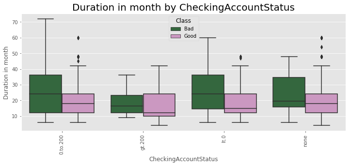

```python
plt.figure(figsize=(12,10))
g2 = plt.subplot(212)
g2 = sns.boxplot(x="CheckingAccountStatus",y="Duration", data=Renamed_data,hue='Class',palette="cubehelix")
g2.set_xlabel("CheckingAccountStatus", fontsize=12)
g2.set_ylabel("Duration in month", fontsize=12)
g2.set_title("Duration in month by CheckingAccountStatus", fontsize=20)
g2.set_xticklabels(g2.get_xticklabels(),rotation=90)

plt.subplots_adjust(wspace = 0.2, hspace = 0.3, top = 0.9)

plt.show()
plt.show()
```

```
Values describe:
Class             Bad  Good
CreditHistory
Critical           50   243
Delay              28    60
NoCredit.AllPaid   25    15
PaidDuly          169   361
ThisBank.AllPaid   28    21
```

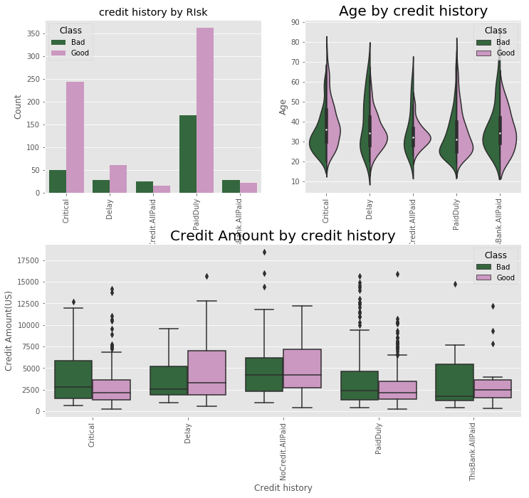

```python
print("Values describe: ")
print(pd.crosstab(Renamed_data.CreditHistory, Renamed_data.Class))

plt.figure(figsize=(12,10))

g=plt.subplot(221)
g = sns.countplot(x='CreditHistory',data=Renamed_data, palette='cubehelix',hue='Class')
g.set_xlabel('Credit history',fontsize=12)
g.set_ylabel('Count',fontsize=12)
g.set_title('credit history by RIsk')
g.set_xticklabels(g.get_xticklabels(),rotation=90)

g1 = plt.subplot(222)
g1 = sns.violinplot(x='CreditHistory',y='Age',data=Renamed_data,palette='cubehelix',hue='Class',split=True)
g1.set_xlabel("Credit history", fontsize=12)
g1.set_ylabel("Age", fontsize=12)
g1.set_title("Age by credit history", fontsize=20)
g1.set_xticklabels(g.get_xticklabels(),rotation=90)

g2 = plt.subplot(212)
g2 = sns.boxplot(x="CreditHistory",y="Amount", data=Renamed_data,hue='Class',palette="cubehelix")
g2.set_xlabel("Credit history", fontsize=12)
g2.set_ylabel("Credit Amount(US)", fontsize=12)
g2.set_title("Credit Amount by credit history", fontsize=20)
g2.set_xticklabels(g.get_xticklabels(),rotation=90)

plt.subplots_adjust(wspace = 0.2, hspace = 0.3, top = 0.9)

plt.show()
plt.show()
```

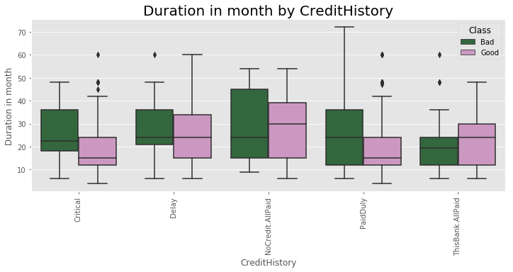

```python
plt.figure(figsize=(12,10))
g2 = plt.subplot(212)
g2 = sns.boxplot(x="CreditHistory",y="Duration", data=Renamed_data,hue='Class',palette="cubehelix")
g2.set_xlabel("CreditHistory", fontsize=12)
g2.set_ylabel("Duration in month", fontsize=12)
g2.set_title("Duration in month by CreditHistory", fontsize=20)
g2.set_xticklabels(g2.get_xticklabels(),rotation=90)

plt.subplots_adjust(wspace = 0.2, hspace = 0.3, top = 0.9)

plt.show()
plt.show()
```

```
Values describe:
Class                Bad  Good
Purpose
Business              34    63
DomesticAppliances     4     8
Education             22    28
Furniture.Equipment   58   123
NewCar                89   145
Others                 5     7
Radio.Television      62   218
Repairs                8    14
Retiring               1     8
UsedCar               17    86
```

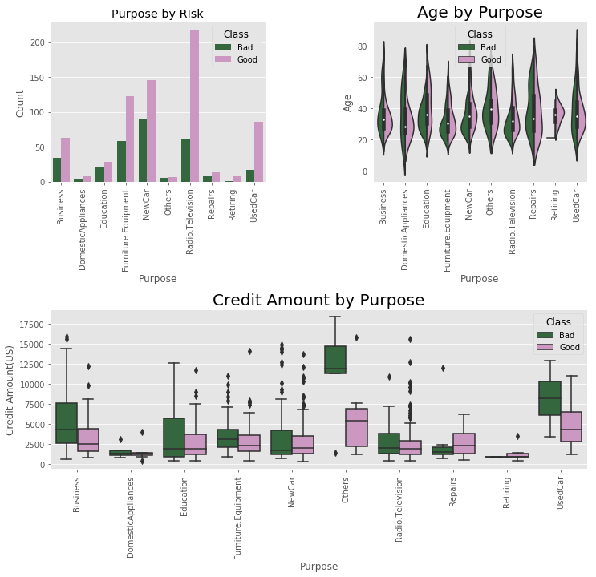

```python
print("Values describe: ")
print(pd.crosstab(Renamed_data.Purpose, Renamed_data.Class))

plt.figure(figsize=(12,10))

g=plt.subplot(221)
g = sns.countplot(x='Purpose',data=Renamed_data, palette='cubehelix',hue='Class')
g.set_xlabel('Purpose',fontsize=12)
g.set_ylabel('Count',fontsize=12)
g.set_title('Purpose by RIsk')
g.set_xticklabels(g.get_xticklabels(),rotation=90)

g1 = plt.subplot(222)
g1 = sns.violinplot(x='Purpose',y='Age',data=Renamed_data,palette='cubehelix',hue='Class',split=True)
g1.set_xlabel("Purpose", fontsize=12)
g1.set_ylabel("Age", fontsize=12)
g1.set_title("Age by Purpose", fontsize=20)
g1.set_xticklabels(g1.get_xticklabels(),rotation=90)

g2 = plt.subplot(212)
g2 = sns.boxplot(x="Purpose",y="Amount", data=Renamed_data,hue='Class',palette="cubehelix")
g2.set_xlabel("Purpose", fontsize=12)
g2.set_ylabel("Credit Amount(US)", fontsize=12)
g2.set_title("Credit Amount by Purpose", fontsize=20)
g2.set_xticklabels(g2.get_xticklabels(),rotation=90)

plt.subplots_adjust(wspace = 0.5, hspace = 0.8, top = 0.9)

plt.show()
plt.show()
```

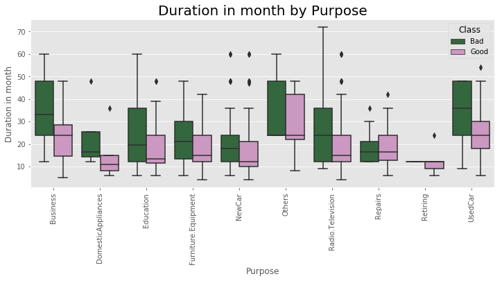

```python
plt.figure(figsize=(12,10))
g2 = plt.subplot(212)
g2 = sns.boxplot(x="Purpose",y="Duration", data=Renamed_data,hue='Class',palette="cubehelix")
g2.set_xlabel("Purpose", fontsize=12)
g2.set_ylabel("Duration in month", fontsize=12)
g2.set_title("Duration in month by Purpose", fontsize=20)
g2.set_xticklabels(g2.get_xticklabels(),rotation=90)

plt.subplots_adjust(wspace = 0.2, hspace = 0.3, top = 0.9)

plt.show()
plt.show()
```

```
Values describe:
Class                Bad  Good
SavingsAccountBonds
100.to.500            34    69
500.to.1000           11    52
Unknown               32   151
gt.1000                6    42
lt.100               217   386
```

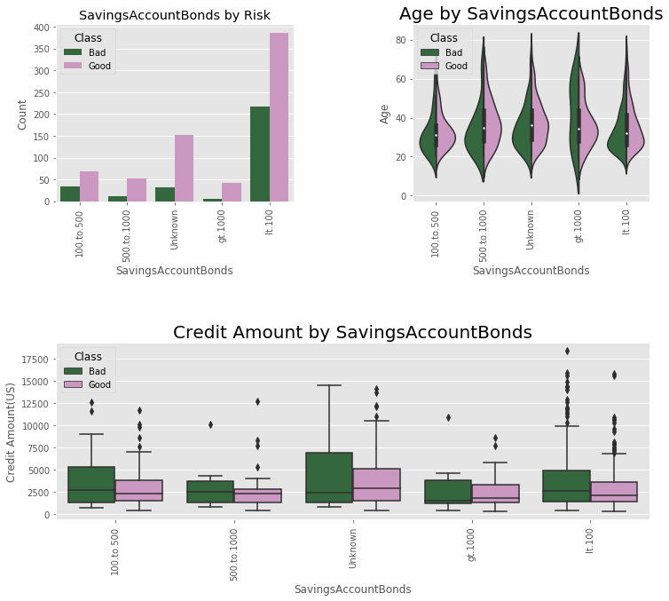

```python
print("Values describe: ")
print(pd.crosstab(Renamed_data.SavingsAccountBonds, Renamed_data.Class))


plt.figure(figsize=(12,10))

g=plt.subplot(221)
g = sns.countplot(x='SavingsAccountBonds',data=Renamed_data, palette='cubehelix',hue='Class')
g.set_xlabel('SavingsAccountBonds',fontsize=12)
g.set_ylabel('Count',fontsize=12)
g.set_title('SavingsAccountBonds by Risk')
g.set_xticklabels(g.get_xticklabels(),rotation=90)

g1 = plt.subplot(222)
g1 = sns.violinplot(x='SavingsAccountBonds',y='Age',data=Renamed_data,palette='cubehelix',hue='Class',split=True)
g1.set_xlabel("SavingsAccountBonds", fontsize=12)
g1.set_ylabel("Age", fontsize=12)
g1.set_title("Age by SavingsAccountBonds", fontsize=20)
g1.set_xticklabels(g1.get_xticklabels(),rotation=90)

g2 = plt.subplot(212)
g2 = sns.boxplot(x="SavingsAccountBonds",y="Amount", data=Renamed_data,hue='Class',palette="cubehelix")
g2.set_xlabel("SavingsAccountBonds", fontsize=12)
g2.set_ylabel("Credit Amount(US)", fontsize=12)
g2.set_title("Credit Amount by SavingsAccountBonds", fontsize=20)
g2.set_xticklabels(g2.get_xticklabels(),rotation=90)

plt.subplots_adjust(wspace = 0.5, hspace = 0.8, top = 0.9)

plt.show()
plt.show()
```

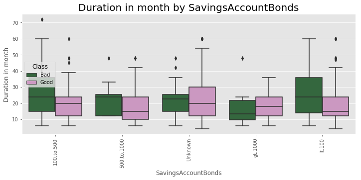

```python
plt.figure(figsize=(12,10))
g2 = plt.subplot(212)
g2 = sns.boxplot(x="SavingsAccountBonds",y="Duration", data=Renamed_data,hue='Class',palette="cubehelix")
g2.set_xlabel("SavingsAccountBonds", fontsize=12)
g2.set_ylabel("Duration in month", fontsize=12)
g2.set_title("Duration in month by SavingsAccountBonds", fontsize=20)
g2.set_xticklabels(g2.get_xticklabels(),rotation=90)

plt.subplots_adjust(wspace = 0.2, hspace = 0.3, top = 0.9)

plt.show()
plt.show()
```

```
Values describe:
Class               Bad  Good
EmploymentDuration
0.to.1               70   102
1.to.4              104   235
4.to.7               39   135
Unemployed           23    39
gt.7                 64   189
```

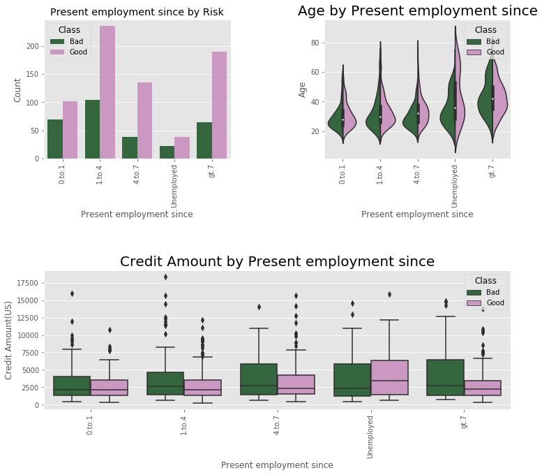

```python
print("Values describe: ")
print(pd.crosstab(Renamed_data.EmploymentDuration, Renamed_data.Class))

plt.figure(figsize=(12,10))

g=plt.subplot(221)
g = sns.countplot(x='EmploymentDuration',data=Renamed_data, palette='cubehelix',hue='Class')
g.set_xlabel('Present employment since',fontsize=12)
g.set_ylabel('Count',fontsize=12)
g.set_title('Present employment since by Risk')
g.set_xticklabels(g.get_xticklabels(),rotation=90)

g1 = plt.subplot(222)
g1 = sns.violinplot(x='EmploymentDuration',y='Age',data=Renamed_data,palette='cubehelix',hue='Class',split=True)
g1.set_xlabel("Present employment since", fontsize=12)
g1.set_ylabel("Age", fontsize=12)
g1.set_title("Age by Present employment since", fontsize=20)
g1.set_xticklabels(g1.get_xticklabels(),rotation=90)

g2 = plt.subplot(212)
g2 = sns.boxplot(x="EmploymentDuration",y="Amount", data=Renamed_data,hue='Class',palette="cubehelix")
g2.set_xlabel("Present employment since", fontsize=12)
g2.set_ylabel("Credit Amount(US)", fontsize=12)
g2.set_title("Credit Amount by Present employment since", fontsize=20)
g2.set_xticklabels(g2.get_xticklabels(),rotation=90)

plt.subplots_adjust(wspace = 0.5, hspace = 0.8, top = 0.9)

plt.show()
plt.show()
```

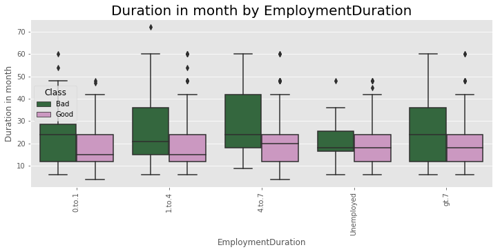

```python
plt.figure(figsize=(12,10))
g2 = plt.subplot(212)
g2 = sns.boxplot(x="EmploymentDuration",y="Duration", data=Renamed_data,hue='Class',palette="cubehelix")
g2.set_xlabel("EmploymentDuration", fontsize=12)
g2.set_ylabel("Duration in month", fontsize=12)
g2.set_title("Duration in month by EmploymentDuration", fontsize=20)
g2.set_xticklabels(g2.get_xticklabels(),rotation=90)

plt.subplots_adjust(wspace = 0.2, hspace = 0.3, top = 0.9)

plt.show()
plt.show()
```

```
Values describe:
Class  Bad  Good
Sex
F      109   201
M      191   499
```

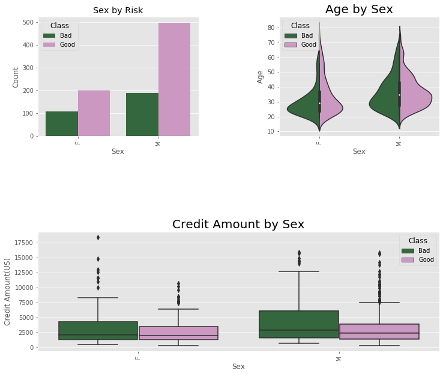

```python
print("Values describe: ")
print(pd.crosstab(Renamed_data.Sex, Renamed_data.Class))

plt.figure(figsize=(12,10))

g=plt.subplot(221)
g = sns.countplot(x='Sex',data=Renamed_data, palette='cubehelix',hue='Class')
g.set_xlabel('Sex',fontsize=12)
g.set_ylabel('Count',fontsize=12)
g.set_title('Sex by Risk')
g.set_xticklabels(g.get_xticklabels(),rotation=90)

g1 = plt.subplot(222)
g1 = sns.violinplot(x='Sex',y='Age',data=Renamed_data,palette='cubehelix',hue='Class',split=True)
g1.set_xlabel("Sex", fontsize=12)
g1.set_ylabel("Age", fontsize=12)
g1.set_title("Age by Sex", fontsize=20)
g1.set_xticklabels(g1.get_xticklabels(),rotation=90)

g2 = plt.subplot(212)
g2 = sns.boxplot(x="Sex",y="Amount", data=Renamed_data,hue='Class',palette="cubehelix")
g2.set_xlabel("Sex", fontsize=12)
g2.set_ylabel("Credit Amount(US)", fontsize=12)
g2.set_title("Credit Amount by Sex", fontsize=20)
g2.set_xticklabels(g2.get_xticklabels(),rotation=90)

plt.subplots_adjust(wspace = 0.5, hspace = 0.8, top = 0.9)

plt.show()
plt.show()
```

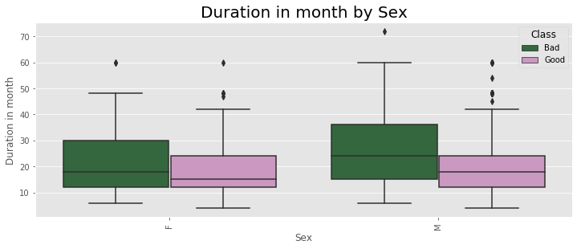

```python
plt.figure(figsize=(12,10))
g2 = plt.subplot(212)
g2 = sns.boxplot(x="Sex",y="Duration", data=Renamed_data,hue='Class',palette="cubehelix")
g2.set_xlabel("Sex", fontsize=12)
g2.set_ylabel("Duration in month", fontsize=12)
g2.set_title("Duration in month by Sex", fontsize=20)
g2.set_xticklabels(g2.get_xticklabels(),rotation=90)

plt.subplots_adjust(wspace = 0.2, hspace = 0.3, top = 0.9)

plt.show()
plt.show()
```

```
Values describe:
Class               Bad  Good
MaritalStatus
Divorced.Seperated   20    30
Married.Widowed      25    67
NotSingle           109   201
Single              146   402
```

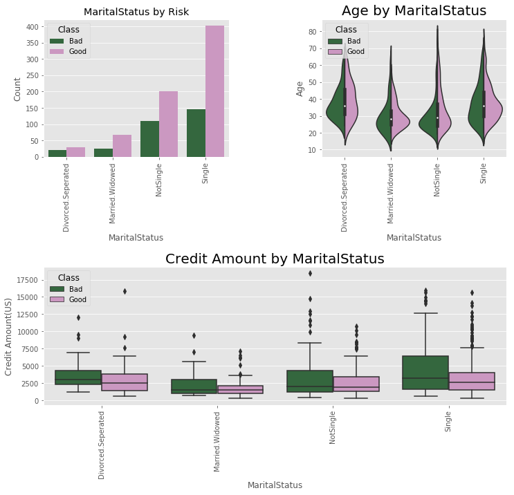

```python
print("Values describe: ")
print(pd.crosstab(Renamed_data.MaritalStatus, Renamed_data.Class))

plt.figure(figsize=(12,10))

g=plt.subplot(221)
g = sns.countplot(x='MaritalStatus',data=Renamed_data, palette='cubehelix',hue='Class')
g.set_xlabel('MaritalStatus',fontsize=12)
g.set_ylabel('Count',fontsize=12)
g.set_title('MaritalStatus by Risk')
g.set_xticklabels(g.get_xticklabels(),rotation=90)

g1 = plt.subplot(222)
g1 = sns.violinplot(x='MaritalStatus',y='Age',data=Renamed_data,palette='cubehelix',hue='Class',split=True)
g1.set_xlabel("MaritalStatus", fontsize=12)
g1.set_ylabel("Age", fontsize=12)
g1.set_title("Age by MaritalStatus", fontsize=20)
g1.set_xticklabels(g1.get_xticklabels(),rotation=90)

g2 = plt.subplot(212)
g2 = sns.boxplot(x="MaritalStatus",y="Amount", data=Renamed_data,hue='Class',palette="cubehelix")
g2.set_xlabel("MaritalStatus", fontsize=12)
g2.set_ylabel("Credit Amount(US)", fontsize=12)
g2.set_title("Credit Amount by MaritalStatus", fontsize=20)
g2.set_xticklabels(g2.get_xticklabels(),rotation=90)

plt.subplots_adjust(wspace = 0.5, hspace = 0.8, top = 0.9)

plt.show()
plt.show()
```

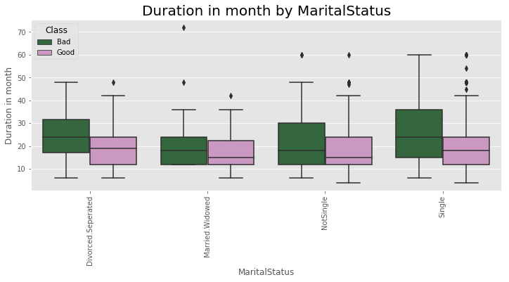

```python
plt.figure(figsize=(12,10))
g2 = plt.subplot(212)
g2 = sns.boxplot(x="MaritalStatus",y="Duration", data=Renamed_data,hue='Class',palette="cubehelix")
g2.set_xlabel("MaritalStatus", fontsize=12)
g2.set_ylabel("Duration in month", fontsize=12)
g2.set_title("Duration in month by MaritalStatus", fontsize=20)
g2.set_xticklabels(g2.get_xticklabels(),rotation=90)

plt.subplots_adjust(wspace = 0.2, hspace = 0.3, top = 0.9)

plt.show()
plt.show()
```

```
Values describe:
Class    Bad  Good
Housing
ForFree   44    64
Own      186   527
Rent      70   109
```

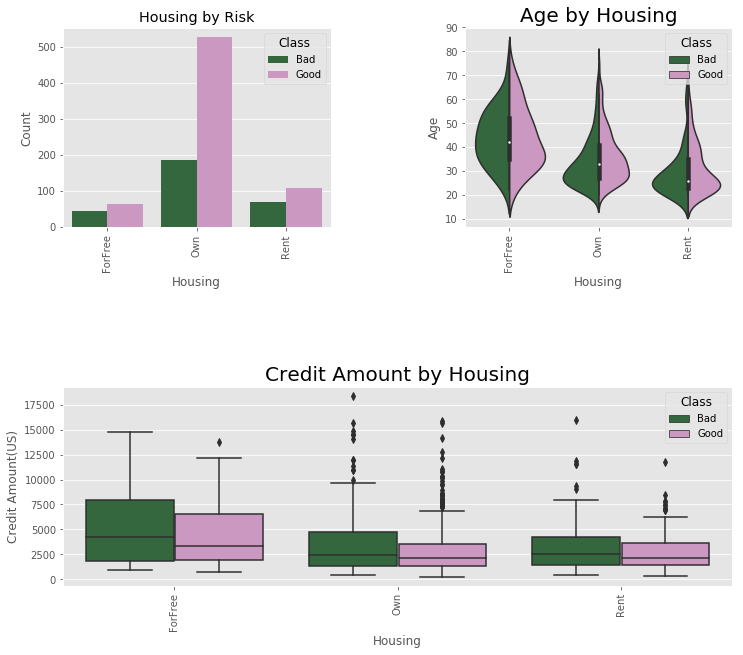

```python
print("Values describe: ")
print(pd.crosstab(Renamed_data.Housing, Renamed_data.Class))

plt.figure(figsize=(12,10))

g=plt.subplot(221)
g = sns.countplot(x='Housing',data=Renamed_data, palette='cubehelix',hue='Class')
g.set_xlabel('Housing',fontsize=12)
g.set_ylabel('Count',fontsize=12)
g.set_title('Housing by Risk')
g.set_xticklabels(g.get_xticklabels(),rotation=90)

g1 = plt.subplot(222)
g1 = sns.violinplot(x='Housing',y='Age',data=Renamed_data,palette='cubehelix',hue='Class',split=True)
g1.set_xlabel("Housing", fontsize=12)
g1.set_ylabel("Age", fontsize=12)
g1.set_title("Age by Housing", fontsize=20)
g1.set_xticklabels(g1.get_xticklabels(),rotation=90)

g2 = plt.subplot(212)
g2 = sns.boxplot(x="Housing",y="Amount", data=Renamed_data,hue='Class',palette="cubehelix")
g2.set_xlabel("Housing", fontsize=12)
g2.set_ylabel("Credit Amount(US)", fontsize=12)
g2.set_title("Credit Amount by Housing", fontsize=20)
g2.set_xticklabels(g2.get_xticklabels(),rotation=90)

plt.subplots_adjust(wspace = 0.5, hspace = 0.8, top = 0.9)

plt.show()
plt.show()
```

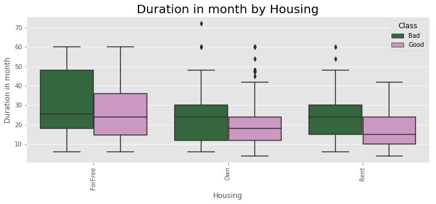

```python
plt.figure(figsize=(12,10))
g2 = plt.subplot(212)
g2 = sns.boxplot(x="Housing",y="Duration", data=Renamed_data,hue='Class',palette="cubehelix")
g2.set_xlabel("Housing", fontsize=12)
g2.set_ylabel("Duration in month", fontsize=12)
g2.set_title("Duration in month by Housing", fontsize=20)
g2.set_xticklabels(g2.get_xticklabels(),rotation=90)

plt.subplots_adjust(wspace = 0.2, hspace = 0.3, top = 0.9)

plt.show()
plt.show()
```

```
Values describe:
Class                               Bad  Good
Job
Management.SelfEmp.HighlyQualified   51    97
SkilledEmployee                     186   444
UnemployedUnskilled                   7    15
UnskilledResident                    56   144
```

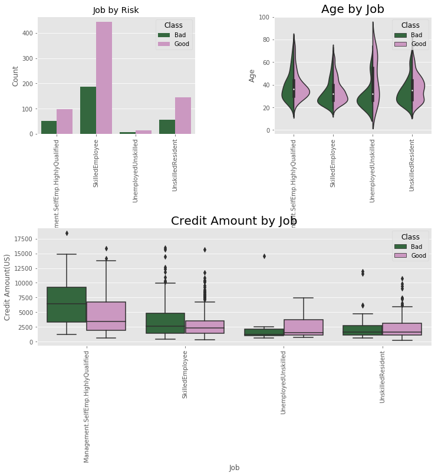

```python
print("Values describe: ")
print(pd.crosstab(Renamed_data.Job, Renamed_data.Class))

plt.figure(figsize=(12,10))

g=plt.subplot(221)
g = sns.countplot(x='Job',data=Renamed_data, palette='cubehelix',hue='Class')
g.set_xlabel('Job',fontsize=12)
g.set_ylabel('Count',fontsize=12)
g.set_title('Job by Risk')
g.set_xticklabels(g.get_xticklabels(),rotation=90)

g1 = plt.subplot(222)
g1 = sns.violinplot(x='Job',y='Age',data=Renamed_data,palette='cubehelix',hue='Class',split=True)
g1.set_xlabel("Job", fontsize=12)
g1.set_ylabel("Age", fontsize=12)
g1.set_title("Age by Job", fontsize=20)
g1.set_xticklabels(g1.get_xticklabels(),rotation=90)

g2 = plt.subplot(212)
g2 = sns.boxplot(x="Job",y="Amount", data=Renamed_data,hue='Class',palette="cubehelix")
g2.set_xlabel("Job", fontsize=12)
g2.set_ylabel("Credit Amount(US)", fontsize=12)
g2.set_title("Credit Amount by Job", fontsize=20)
g2.set_xticklabels(g2.get_xticklabels(),rotation=90)

plt.subplots_adjust(wspace = 0.5, hspace = 0.8, top = 0.9)

plt.show()
plt.show()
```

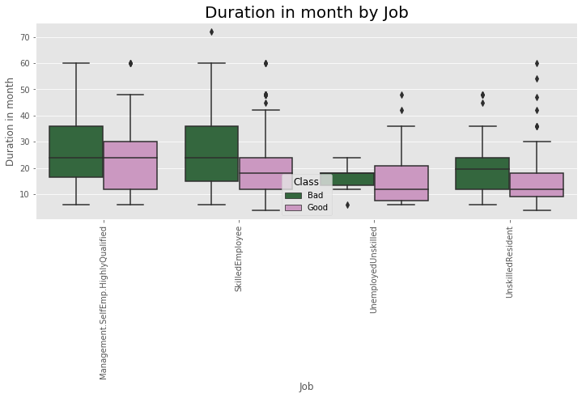

```python
plt.figure(figsize=(12,10))
g2 = plt.subplot(212)
g2 = sns.boxplot(x="Job",y="Duration", data=Renamed_data,hue='Class',palette="cubehelix")
g2.set_xlabel("Job", fontsize=12)
g2.set_ylabel("Duration in month", fontsize=12)
g2.set_title("Duration in month by Job", fontsize=20)
g2.set_xticklabels(g.get_xticklabels(),rotation=90)

plt.subplots_adjust(wspace = 0.2, hspace = 0.3, top = 0.9)

plt.show()
plt.show()
```

```
Values describe:
Class          Bad  Good
ForeignWorker
0                4    33
1              296   667
```

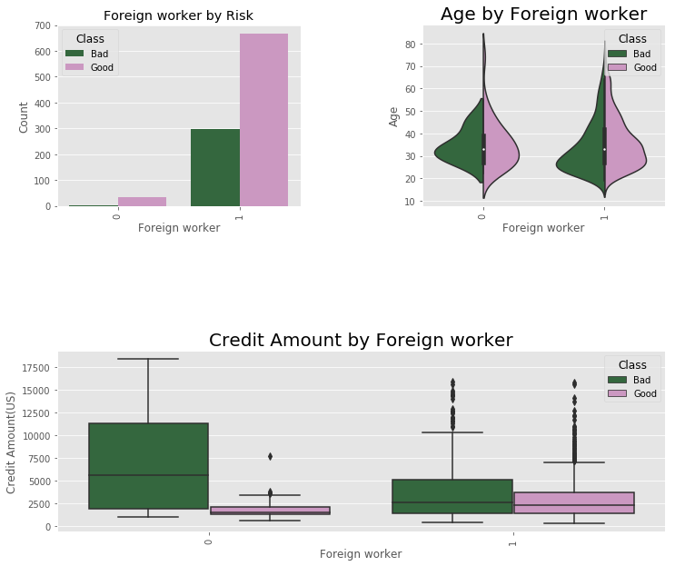

```python
print("Values describe: ")
print(pd.crosstab(Renamed_data.ForeignWorker, Renamed_data.Class))

plt.figure(figsize=(12,10))

g=plt.subplot(221)
g = sns.countplot(x='ForeignWorker',data=Renamed_data, palette='cubehelix',hue='Class')
g.set_xlabel('Foreign worker',fontsize=12)
g.set_ylabel('Count',fontsize=12)
g.set_title('Foreign worker by Risk')
g.set_xticklabels(g.get_xticklabels(),rotation=90)

g1 = plt.subplot(222)
g1 = sns.violinplot(x='ForeignWorker',y='Age',data=Renamed_data,palette='cubehelix',hue='Class',split=True)
g1.set_xlabel("Foreign worker", fontsize=12)
g1.set_ylabel("Age", fontsize=12)
g1.set_title("Age by Foreign worker", fontsize=20)
g1.set_xticklabels(g1.get_xticklabels(),rotation=90)

g2 = plt.subplot(212)
g2 = sns.boxplot(x="ForeignWorker",y="Amount", data=Renamed_data,hue='Class',palette="cubehelix")
g2.set_xlabel("Foreign worker", fontsize=12)
g2.set_ylabel("Credit Amount(US)", fontsize=12)
g2.set_title("Credit Amount by Foreign worker", fontsize=20)
g2.set_xticklabels(g2.get_xticklabels(),rotation=90)

plt.subplots_adjust(wspace = 0.5, hspace = 0.8, top = 0.9)

plt.show()
plt.show()
```

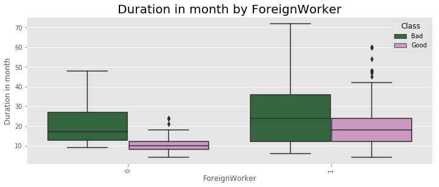

```python
plt.figure(figsize=(12,10))
g2 = plt.subplot(212)
g2 = sns.boxplot(x="ForeignWorker",y="Duration", data=Renamed_data,hue='Class',palette="cubehelix")
g2.set_xlabel("ForeignWorker", fontsize=12)
g2.set_ylabel("Duration in month", fontsize=12)
g2.set_title("Duration in month by ForeignWorker", fontsize=20)
g2.set_xticklabels(g.get_xticklabels(),rotation=90)

plt.subplots_adjust(wspace = 0.2, hspace = 0.3, top = 0.9)

plt.show()
plt.show()
```

```python
%matplotlib inline
import numpy as np
```

```python
file_num_url = 'https://archive.ics.uci.edu/ml/machine-learning-databases/statlog/german/german.data-numeric'
urlretrieve(file_num_url, 'german.data-numeric')
```

```
('german.data-numeric', <http.client.HTTPMessage at 0x1a1f356fd0>)
```

```python
data_numeric = pd.DataFrame(np.genfromtxt('german.data-numeric'))
```

```python
print(data_numeric.head(5))
```

```
    0     1    2     3    4    5    6    7    8     9  ...    15   16   17  \
0  1.0   6.0  4.0  12.0  5.0  5.0  3.0  4.0  1.0  67.0 ...   0.0  0.0  1.0
1  2.0  48.0  2.0  60.0  1.0  3.0  2.0  2.0  1.0  22.0 ...   0.0  0.0  1.0
2  4.0  12.0  4.0  21.0  1.0  4.0  3.0  3.0  1.0  49.0 ...   0.0  0.0  1.0
3  1.0  42.0  2.0  79.0  1.0  4.0  3.0  4.0  2.0  45.0 ...   0.0  0.0  0.0
4  1.0  24.0  3.0  49.0  1.0  3.0  3.0  4.0  4.0  53.0 ...   1.0  0.0  1.0

    18   19   20   21   22   23   24
0  0.0  0.0  1.0  0.0  0.0  1.0  1.0
1  0.0  0.0  1.0  0.0  0.0  1.0  2.0
2  0.0  0.0  1.0  0.0  1.0  0.0  1.0
3  0.0  0.0  0.0  0.0  0.0  1.0  1.0
4  0.0  0.0  0.0  0.0  0.0  1.0  2.0

[5 rows x 25 columns]
```

```python
X,y=data_numeric.iloc[:,0:23],data_numeric.iloc[:,24]
```

```python
X.shape
```

```
(1000, 23)
```

```python
y.shape
```

```
(1000,)
```

```python
from sklearn.cross_validation import train_test_split
X_train, X_test, y_train, y_test = train_test_split(X, y, random_state=0,test_size=0.3)
```

```python
# train a logistic regression model on the training set
from sklearn.linear_model import LogisticRegression

# instantiate model
logreg = LogisticRegression()

# fit model
logreg.fit(X_train, y_train)
```

```
LogisticRegression(C=1.0, class_weight=None, dual=False, fit_intercept=True,
          intercept_scaling=1, max_iter=100, multi_class='ovr', n_jobs=1,
          penalty='l2', random_state=None, solver='liblinear', tol=0.0001,
          verbose=0, warm_start=False)
```

```python
# make class predictions for the testing set
y_pred_class = logreg.predict(X_test)
```

- **Classification accuracy**: percentage of correct predictions

```python
# calculate accuracy
from sklearn import metrics
print(metrics.accuracy_score(y_test, y_pred_class))
```

```
0.77
```

- Classification accuracy is 77%
- **Null accuracy**: accuracy that could be achieved by always predicting the most frequent class
- We must always compare with this

```python
# examine the class distribution of the testing set (using a Pandas Series method)
y_test.value_counts()
```

```
1.0    214
2.0     86
Name: 24, dtype: int64
```

```python
#percentage of 1 and 2
y_test.value_counts(normalize=True)
```

```
1.0    0.713333
2.0    0.286667
Name: 24, dtype: float64
```

```python
# calculate null accuracy in a single line of code
# only for binary classification problems coded as 1/2
max(0.287, 0.713)
```

```
0.713
```

- This means that a dumb model that always predicts 1 would be right 71% of the time
- This shows how classification accuracy is not that good as it's close to a dumb model.
- It's a good way to know the minimum we should achieve with our models.

```python
# calculate null accuracy (for multi-class classification problems)
y_test.value_counts().head(1) / len(y_test)
```

```
1.0    0.713333
Name: 24, dtype: float64
```

Comparing the true and predicted response values

```python
# print the first 25 true and predicted responses
print('True:', y_test.values[0:25])
print('Predicted:', y_pred_class[0:25])
```

```
True: [1. 1. 1. 1. 1. 1. 1. 1. 1. 2. 2. 2. 1. 1. 2. 1. 1. 2. 1. 1. 1. 1. 1. 1.
 1.]
Predicted: [2. 1. 1. 1. 2. 1. 1. 1. 1. 2. 2. 2. 1. 1. 2. 1. 1. 1. 2. 1. 2. 2. 1. 1.
 1.]
```

#### Conclusion:

- Classification accuracy is the easiest classification metric to understand,
- But, it does not tell you the underlying distribution of response values.
- We examine by calculating the null accuracy.
- And, it does not tell you what "types" of errors your classifier is making

## Confusion matrix

```python
# IMPORTANT: first argument is true values, second argument is predicted values
# this produces a 2x2 numpy array (matrix)
print(metrics.confusion_matrix(y_test, y_pred_class))
```

```
[[183  31]
 [ 38  48]]
```

#### Every observation in the testing set is represented in exactly one box.

- It's a 2x2 matrix because there are 2 response classes
- The format shown here is not universal
- Take attention to the format when interpreting a confusion matrix

#### Basic terminology

```python
# print the first 25 true and predicted responses
print('True', y_test.values[0:25])
print('Pred', y_pred_class[0:25])
```

```
True [1. 1. 1. 1. 1. 1. 1. 1. 1. 2. 2. 2. 1. 1. 2. 1. 1. 2. 1. 1. 1. 1. 1. 1.
 1.]
Pred [2. 1. 1. 1. 2. 1. 1. 1. 1. 2. 2. 2. 1. 1. 2. 1. 1. 1. 2. 1. 2. 2. 1. 1.
 1.]
```

```python
# save confusion matrix and slice into four pieces
confusion = metrics.confusion_matrix(y_test, y_pred_class)
print(confusion)
#[row, column]
TN = confusion[1, 1]
TP = confusion[0, 0]
FN = confusion[0, 1]
FP = confusion[1, 0]
FP
```

```
[[183  31]
 [ 38  48]]
```

```
38
```

### Metrics computed from a confusion matrix

- **Classification Accuracy**: Overall, how often is the classifier correct?

```python
# use float to perform true division, not integer division
print((TP + TN) / float(TP + TN + FP + FN))
print(metrics.accuracy_score(y_test, y_pred_class))
```

```
0.77
0.77
```

#### Classification Error: Overall, how often is the classifier incorrect?

- Also known as "Misclassification Rate"

```python
classification_error = (FP + FN) / float(TP + TN + FP + FN)

print(classification_error)
print(1 - metrics.accuracy_score(y_test, y_pred_class))
```

```
0.23
0.22999999999999998
```

**Sensitivity**: When the actual value is positive, how often is the prediction correct?

```
* Something we want to maximize
* How "sensitive" is the classifier to detecting positive instances?
* Also known as "True Positive Rate" or "Recall"
* TP / all positive
* all positive = TP + FN
```

```python
sensitivity = TP / float(FN + TP)

print(sensitivity)
print(metrics.recall_score(y_test, y_pred_class,labels=[2.,1.]))
```

```
0.8551401869158879
0.8551401869158879
```

- **Specificity**: When the actual value is negative, how often is the prediction correct?
- Something we want to maximize
  - How "specific" (or "selective") is the classifier in predicting positive instances?
  - TN / all negative
    - all negative = TN + FP

```python
specificity = TN / (TN + FP)

print(specificity)
```

```
0.5581395348837209
```

- **False Positive Rate** : When the actual value is negative, how often is the prediction incorrect?

```python
false_positive_rate = FP / float(TN + FP)

print(false_positive_rate)
print(1 - specificity)
```

```
0.4418604651162791
0.4418604651162791
```

**Precision**: When a positive value is predicted, how often is the prediction correct?

```
* How "precise" is the classifier when predicting positive instances?
```

```python
precision = TP / float(TP + FP)

print(precision)
print(metrics.precision_score(y_test, y_pred_class))
```

```
0.8280542986425339
0.8280542986425339
```